# Final project

Jerry Guo, Yuteng Ma, Janice Ye

2024-04-09

## Rationale

Wildfires are serious natural disasters that are often caused by human activity or a natural phenomenon such as lightning, and they can happen at any time or anywhere (https://www.cisa.gov/topics/critical-infrastructure-security-and-resilience/extreme-weather-and-climate-change/wildfires). Although wildfire occurs naturally and can play an important role in the health of our ecosystem, the west coast of the United States, especially California, has been impacted severely by increasing incidents. Climate change further upsets the status quo, and wildfire occurrences have grown globally (https://www.wri.org/insights/global-trends-forest-fires). The cause of wildfires is complex and varies geographically.

This project focuses on wildfire incidents in California to infer the trends and patterns of wildfires in the recent decade. Then, we will evaluate the effectiveness of wildfire-targeted programs based on the number of wildfire incidents and casualties. The objective is to understand the pattern of wildfires. Understanding this pattern could help us reduce the frequency of wildfire incidents and thus protect the welfare of affected communities. This study also helps to evaluate the effectiveness of existing programs.

## Research Questions

Question 1: Has there been an overall increase in wildfire incidents in California in recent decade?

Question 2: Is there a pattern of wildfire incidents? For example, where in California has more wildfire incidents?

Question 3: Is state or federal programs that aim to mitigate wildfire incidents effective at decreasing casualties?

## Data Information

For this study, our group will utilize data downloaded from the California Department of Forestry and Fire Protection (Cal Fire). The data dates all the way back to 2013, and we will analyze the data from every five years. The dataset contains information on fire accidents, including name, location, time of occurrence, affected area, etc. These values can support our research questions by providing empirical data for analyzing trends, the effectiveness of firefighting efforts, impact assessment, and resource allocation. Detailed description of each variable will be listed below:

Incident Name: Unique identifiers for each incident, useful for tracking and referencing specific events

Incident County: Exact incident locations enable spatial analysis and mapping, which is crucial for identifying hotspots and predicting future incidents

Incident Acres Burned: A direct measure of an incident’s size, vital for assessing impact and the effectiveness of programs

```
Longitude: Same as “Incident County”

Latitude: Same as “Incident County”
```

Date Created: Along with “Date extinguished,” will help us to identify which season/month wildfire is more common

```
Date Extinguished: See as above
```

## Exploratory Analysis

### Set Up

First, we will set up the theme and load all the packages we need for the project.

### Import Data as Dataframe

We will use the data information from this website: “https://www.fire.ca.gov/incidents” Since this website provide its up-to-date data, we will download it and use it for our research purpose. Scroll all the way down to “Incident Data”, download the data by clicking “all data as csv.”

### First Plot of Acres Burned

Now we want to have a initial glimpse of how the incident acres burned looks like:

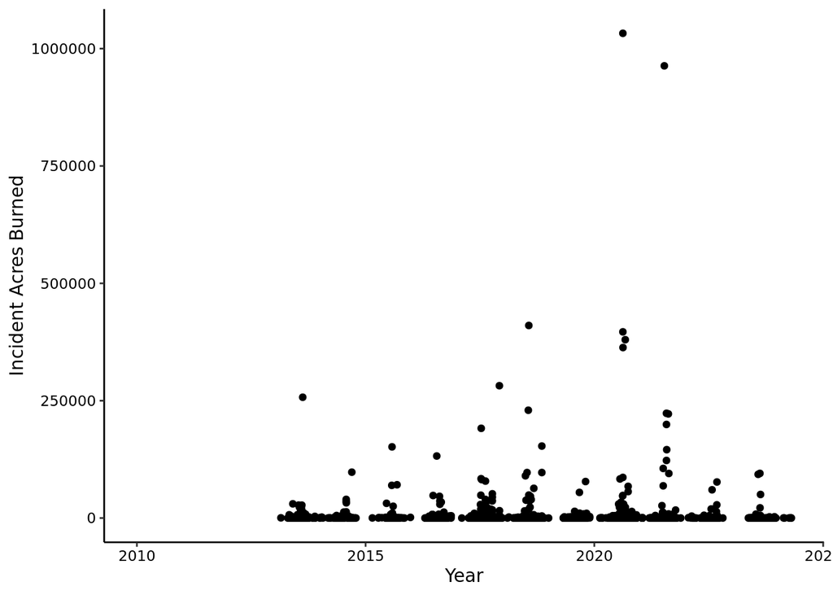

Table 1, Acres Burned

### Revising Dataframe

This is a bad plot where is shows almost no valuable information for us to see. In fact, the original plot is even worse for it contains data back in 1970s with no useful value, so we decided to separate the raw dataset into two data sets, first one contains date from 2013 to the end of 2018, second one contains data from 2019 to recent.

Now we want to plot it to see if our range is better:

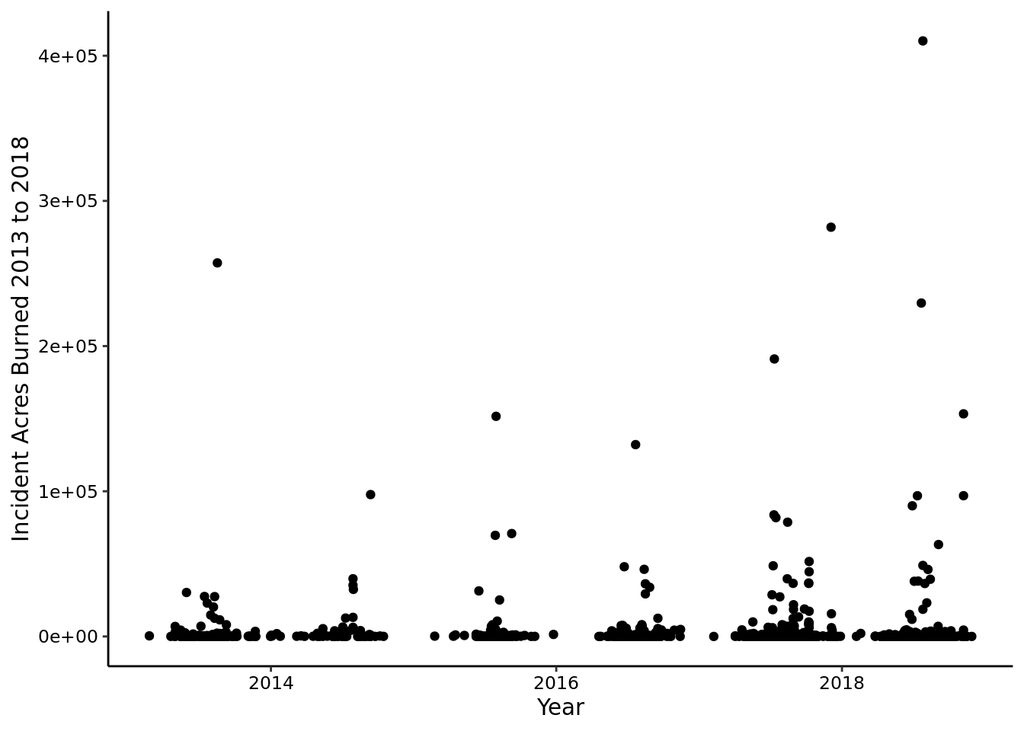

Table 2 Acres Burned 2013 to 2018

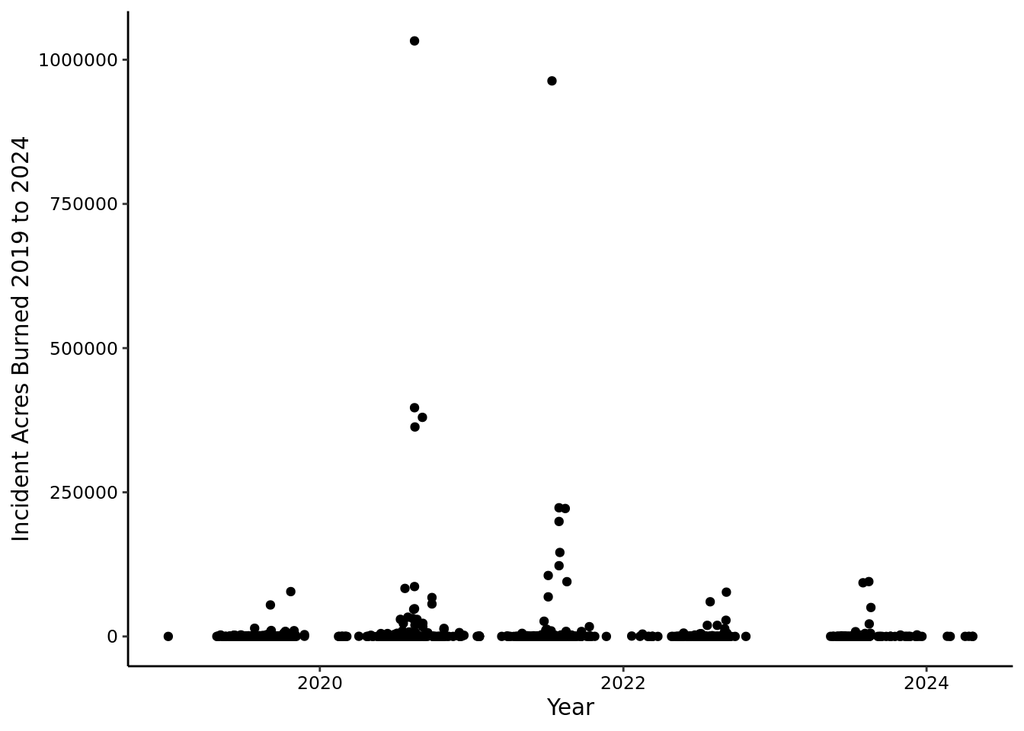

The new graph which contains data from 2013 to 2018 shows the acres burned by each incidents. Based on the scatter plot, we can see that incidents in 2018 burned more acres compared to other years as its data is more spread out across the y-axis. Data points from other years are more concentrated near the x-axis with few outliers, indicating less damage.

However, this is still not a favorable plot for visualization since some incident burned too much acres, so we want to statistically define what is outlier, then create plots without outliers, and also show which date has the outlier. We decided to define outlier as any value that is greater than the third quartile + 1.5 * the inner quartile value, and excluded these value from our data to further explore the incidents.

### Plot of Acres Burned from 2013 to 2018

After excluding the outliers, we used a scatter plot to further explore our data.

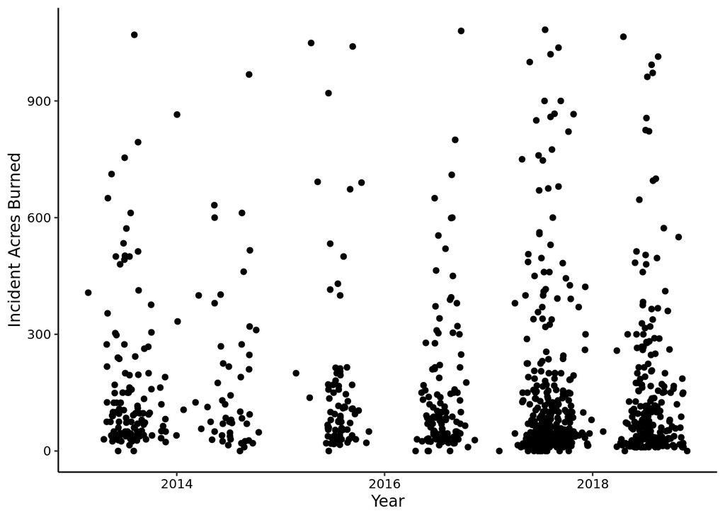

Table 4, Acres Burned 2013 to 2018

The new graph which contains data from 2013 to 2018 shows the acres burned by each incidents. Based on the scatter plot, we can see that incidents in 2018 burned more acres compared to other years as its data is more spread out across the y-axis. Data points from other years are more concentrated near the x-axis with few outliers, indicating less damage. To ensure this prediction, we tried again with box plot for better visualization.

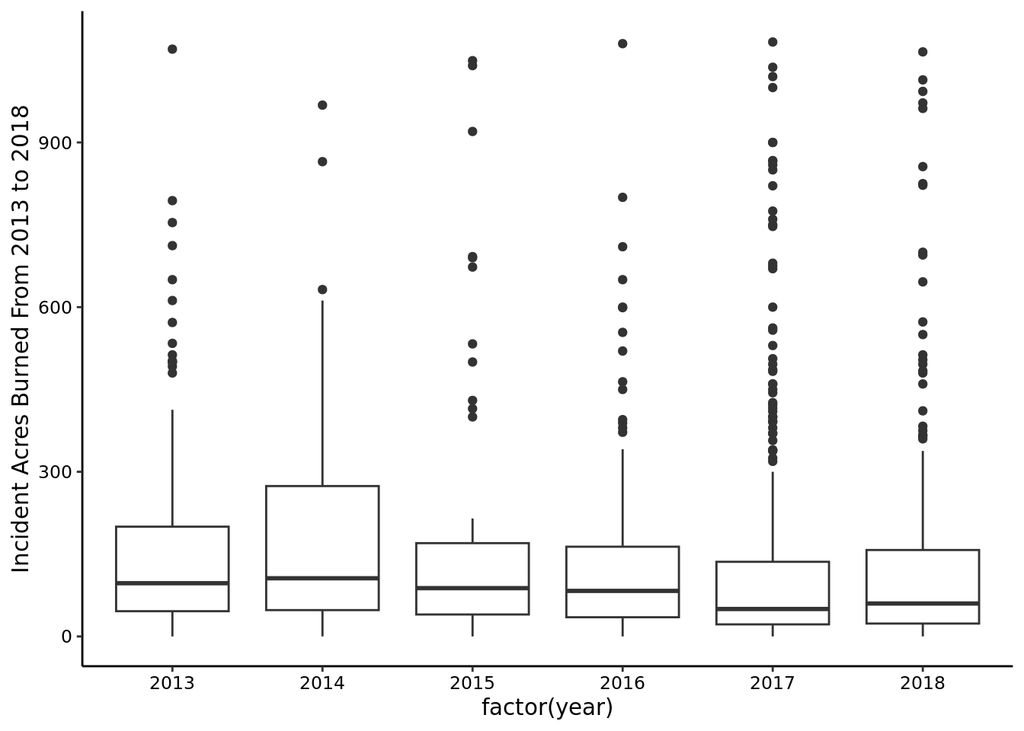

Table 5, Acres Burned Boxplot 2013 to 2018

Now we will plot the data from 2019 to the present

### Plot of Acres Burned from 2019 to 2024

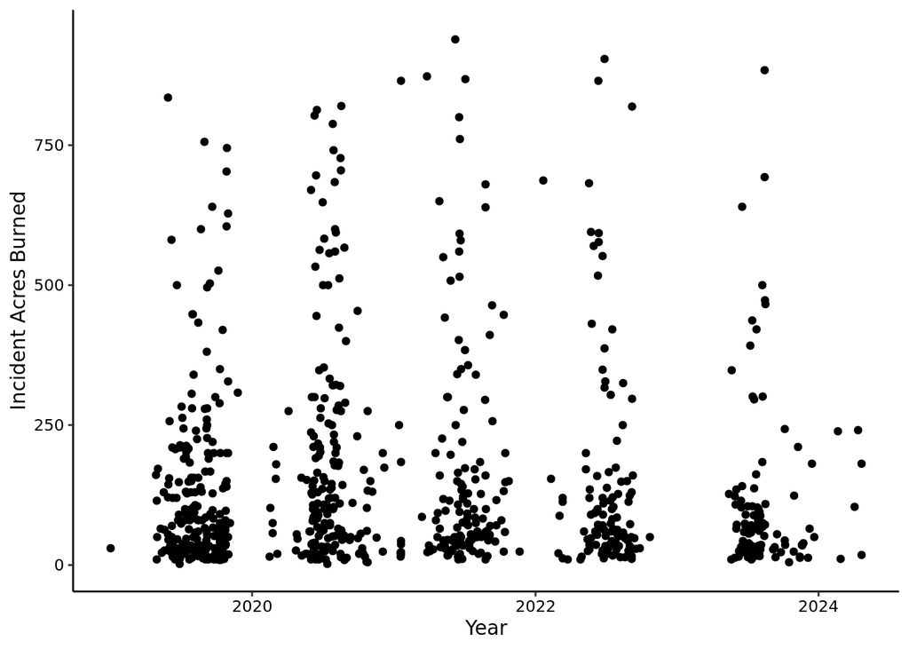

Table 6, Acres Burned 2019 to 2024

This plot graph lacks clarity to identify any pattern. It looks like 2024 has a lot less acres burned in incidents. To confirm this, we will try plot the data again with box plot.

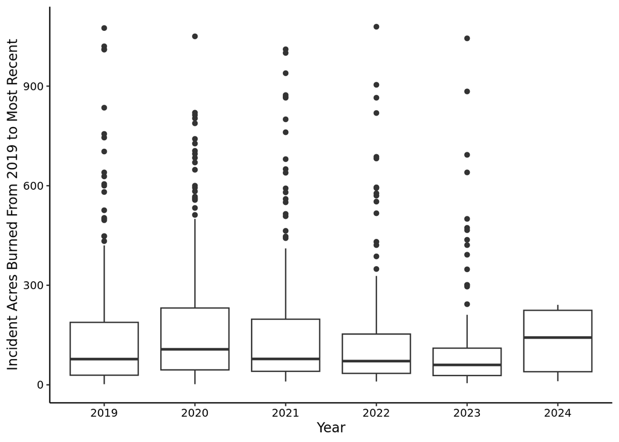

Table 7, Acres Burned Boxplot from 2019 to 2024

Based on this box plot, we cannot confirm that 2024 has less acres burned in incidents but we can state that 2024 has a lot less severe incidents since it has no tail compared to other years. 2023 is the year that suffers from the least acres burned because its average is less than the average of other years.

### Frequency of Incidents

Now we will look at the frequency of incidents. Because we already know that fire incidents back in 1970s greatly influence our data, we will only focus on the data after 2013 to focus more on recent decades.

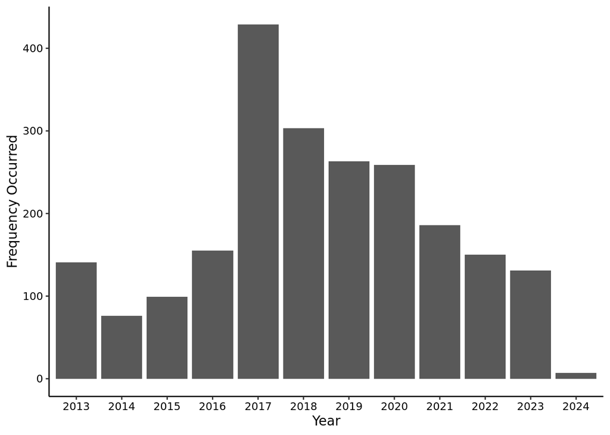

Table 8, Incident Frequency

We used a bar plot to show the incidents happened for each year. According to the results, 2017 had the most incidents,in number of 483,116 total emergency responses, and the most destroyed structures,in number of 10,868 structures destroyed. The overall trend after 2017 is decreasing, however the year followed has more loss of life. All in all, compared to recent years, 2017 still has the highest frequency.

Now, we will identify the duration of each fire incident

```
## Time difference of 67.2789 days
```

The average duration of all fire incidents reported is 67.

### Spatial Analysis

Now we will conduct a spatial analysis trying to identify the geographic pattern of wildfires.

[figure not shown]

Table 10, Map of Incidents

[interactive chart not shown]

Since the data only contains report within the state of California, we will treat any point that is outside of California as an error. Although wildfire is common across California, we can see that incidents in northern California are more spread across state while incidents in southern California is more concentrated along the coast. But this might not be significant enough to identify a pattern. Thus, we decided to look at the top 20 largest fire incidents.

After we see fire incidents based on their specific location

[interactive chart not shown]

### Casualty

Now, we will explore the number of casualty throughout the years to identify if fire prevention programs effectively reduced the number of casualty. Since casualty number is not provided in the dataset we downloaded, we will manually scrape the data from the official website.

Scrap all years displayed on the website

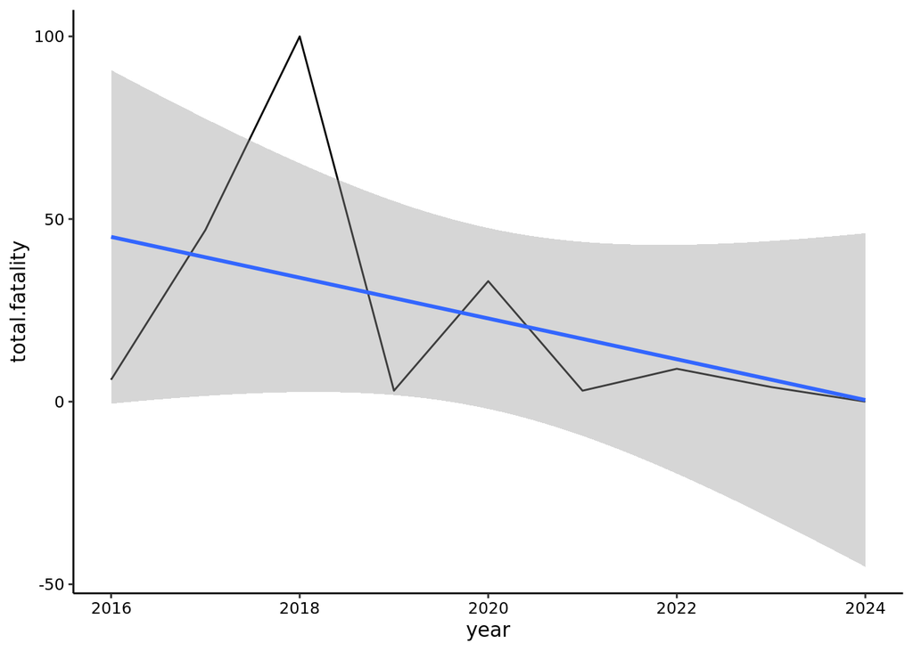

Table 12, Number of Casualty

We scrapped all casualty data from 2016 to 2024 (2016 was the first year that provides the number of casualty). We can see that there is a huge spike in 2018 and after that, the overall trend shows a decreasing pattern.

## Analysis

In the study, we tried to explore the severity of wildfire incidents in California. Our research methodology consisted of three key phases aimed at comprehensively analyzing the severity of wildfire incidents in California and the effectiveness of prevention programs.

## Reference

“California Department of Forestry and Fire Protection | CAL FIRE,” n.d. https://www.fire.ca.gov/. “Wildfires & Climate Change | California Air Resources Board,” n.d. https://ww2.arb.ca.gov/wildfires-climate-change. Grubbs Law Firm. “How Did the Dixie Fire Start? | Grubbs Law Firm,” October 4, 2023. https://grubbs-law.com/dixie-fire-california/#:~:text=More%20than%201%2C200%20structures%20were,utility%20poles%20with%20faulty%20fuses. “August Complex Wildfire and the Round Valley Indian Reservation in Northern California - RHIhub Emergency Preparedness Toolkit,” n.d. https://www.ruralhealthinfo.org/toolkits/emergency-preparedness/case-studies/natural-disasters/round-valley-indian-reservation.